# Coursework Report

*N* removed NAs: 3

*N* removed typo: 1

*N* removed <18: 13

*N* total clean: 133

| Group | *N* | *M*<sub>age</sub> | *M*<sub>rating</sub> |
| --- | --- | --- | --- |
| Control | 70 | 21.1 | 5.27 |
| Experim | 63 | 21.1 | 6.29 |

**Main analysis results**

*t*(131) = -7.28, *p* < .001

[interactive chart not shown]

[figure not shown]

[interactive chart not shown]

# Coursework Report

Analysing Data, Spring 2020

# Methods

## Participants

Table 1: Descriptive Statistics by Experimental Condition

| CONDITION | n | Percentage | *M*~age | *SD*~age |
| --- | --- | --- | --- | --- |
| control | 70 | 52.6 | 21.1 | 1.90 |
| experimental | 63 | 47.4 | 21.1 | 1.87 |

## Design

The conceptual hypothesis for this study was “Does colour influence attractiveness?”. There were two operationalised variables within this study, colour and attractiveness. To operationalise the independent categorical variable ‘colour’, there were two levels, a red background for the experimental condition and a white background for the control condition. Participants only viewed one of the two levels. Colour (the independant categorical variable) was the predicor and was manipulated.

Attractiveness, the continuous variable, was a rating on a scale from 1 to 9 to three different questions, with 9 being the highest score and meaning more attractive. Attractiveness was the outcome of manipulating the colour of the background (either white or red). The three questions which participants rated their answers to on the 1-9 scale were ‘How attractive do you think this person is?’, ‘How pleasant is this person to look at?’ and ‘If I were to meet the person in this picture face to face, I would think think he is attractive’. These three answers were averaged and gave us a composite score. The operational hypothesis for this study was ‘By viewing an image of a moderately attractive male that is surrounded by a different colour frame, does this have an influence on the mean ratings of his attractiveness’.

# Results

The results from this experiment indicate that the percieved attractiveness of a male was rated higher by the participants in the experimental group, who saw the picture of the man displayed in front of a red background, rather than in the control group, where the man was displayed in front of a white background. This result was clear from working out the composite mean scores for both groups. The composite mean scores indicated that the experimental group (red background) scored higher on the attractiveness rating scale of 1 to 9, than the control group (white background). Below is a table showing the composite scores for both groups.

Table 2: Composite Score by Group

| GROUP | mean | sd | min | max |
| --- | --- | --- | --- | --- |
| control | 5.27 | 0.83 | 3.00 | 7.33 |
| experimental | 6.29 | 0.78 | 4.33 | 8.00 |

The composite scores above were calculated by taking each participant’s scores to the three questions they were asked and then calculating the mean of the three scores. Then, each participant’s mean score was grouped by group (control or experimental) to give an overall summary of the mean and sd. The composite scores were then used to create a means plot, that indicates the variation in the means for both groups. The means plot is presented below.

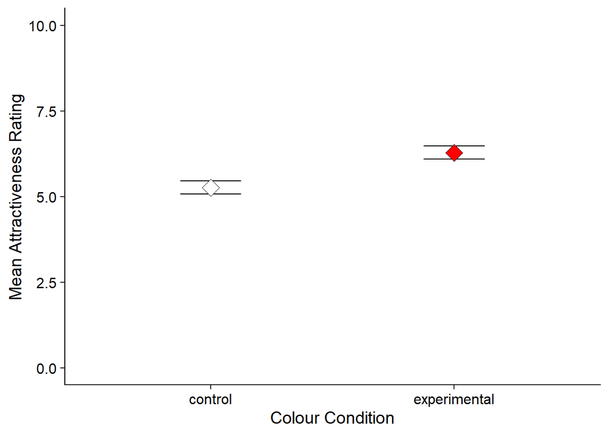

# Discussion

The results from this study indicated that men are deemed more attractive when placed in front of a red coloured background than a white background. The original research question we wanted to analyse was ‘By viewing an image of a moderately attractive male that is surrounded by a different colour frame, does this have an influence on the mean ratings of his attractiveness?’ and our statistical result (*t*-test) answered this question. The *t*-test result demonstrated that in conjunction with the colour red, males are deemed more attractive, rather than in conjunction with the colour white.

The results from this study are similar to the original Elliot et al. (2010) study that we replicated. In Experiment 1 (Elliot et al., 2010), their pattern of results revealed that the colour red influences participants’ ratings of male attractiveness more than white (a neutral and achromatic colour) which was similar to the results we obtained. Overall, this suggests that when a male is placed in front of a red background his percieved attractiveness by females increases. However, Francis (2013) stated that Eliot et al. (2010) research contained possible publication bias and perhaps did not report all experiments with null findings as well as running experiments that increased the likelihood of rejecting the null hypothesis, therefore we cannot be sure that our pattern of results are the same as those of Elliot et al. (2015).

The results from this experiment do not compare to some other replication attempts of the original Elliot et al. (2010) paper. Hesslinger, Goldbach et Carbon (2015) found that red had no impact on perceived male attractiveness for females but instead, apparel style choices (eg.formal or casual) did have an effect. Hesslinger, Goldback and Carbon (2015) discovered that a formal apparel style on a male gave them a higher attractiveness rating than a casual style. Therefore, perhaps future studies should look into the effect that red formal clothing has on percieved male attractiveness, as apparel style choices seem to affect percieved attractiveness in real life (Hesslinger, Goldback & Carbon 2015). Therefore, we could suggest that the results we obtained are not ecologically valid, as they are not considering factors (eg.clothing choices) that often have an influence on male attractiveness in normal real life. Additionally, Hill, Nocks and Gardner (1987) also found that males who display higher status in their apparel choices can enhance different attractiveness measures (eg. dating, sexual or physical) in certain circumstances. This highlights the importance of apparel in male attractiveness and therefore is worth investigating further in conjunction with the red effect.

A clear strength of this replication study is that the findings matched that of Eliot et al. (2015) and demonstrate that the colour red does have an effect on percieved male attractiveness, despite the accusations of publication bias (Francis, 2013). A limitation of this study is the use of just one moderately attractive man presented to each group (experimental or control). This is a limitation as this one male photograph does not reflect the variability of physical appearance found in reality (Hessinger, Goldback & Carbon, 2015). The ‘moderately attractive’ male photograph used in our study may have been deemed as completely unattractive to some participants and characteristics of his physical appearance (eg. hair colour) may have been the reason for giving him low scores to the three proposed questions. Thus, the scores from the experiment might not be due to the influence of the background colour (red or white) but instead personal preferences on physical appearence. Consequently, in future studies perhaps researchers should conduct an interview or questionnaire prior to participants seeing a picture of a male so that they can give the researchers an idea of what their “type” is, so that they are given a picture of a male that each individual participant finds moderately attractive.This would therefore attempt to cover the variabilty of physical appearance found in real life and the different characteristics individuals find more attractive.

I think researching into the effects of the colour red is worth investigating further. Future research can have important implications for advertising and sales and looking into whether products are more likely to be bought with red packaging or an achromatic colour packaging. Research into the red effect may benefit fashion businesses who may use evidence of the red effect to create collections for romantic events or dates. Additionally, as mentioned earlier, I think future research should concentrate on the red effect on male clothing since Elliot and Niesta (2008) found women had higher attractiveness ratings when dressed in a red shirt, indicating red clothing can affect percieved attractiveness.

Overall, I believe the results of this study answered our original research question “By viewing an image of a moderately attractive male that is surrounded by a different colour frame, does this have an influence on the mean ratings of his attractiveness?”, as the results demonstrated that a red background does have an effect on the percieved attractiveness of a male, and further emphasing the existance of the “red effect”. Next steps researchers should make should look into the red effect on clothing and how that makes someone appear more attractive, as well as important implications the ‘red effect’ may have for sales, advertising and fashion, where findings of the red effect might have applied value.

# References

Elliot, A. J., Niesta Kayser, D., Greitemeyer, T., Lichtenfeld, S., Gramzow, R. H., Maier, M. A., & Liu, H. (2010). Red, rank, and romance in women viewing men. *Journal of Experimental Psychology: General, 139*(3), 399.

Elliot, A. J., Niesta, D. (2008). Romantic red: Red enhances men’s attraction to women. *Journal of Personality and Social Psychology, 95*, 1150–1164.

Francis, G. (2013). Publication bias in “Red, rank, and romance in women viewing men,” by Elliot et al. (2010). *Journal of experimental psychology. General, 142*(1), 292-6

Hesslinger, V. M., Goldback, L., Carbon, C. (2015). Men in red: A reexamination of the red-attractiveness effect. *Psychol BullRev 22,*, 1142 - 1148.

Hill, E. M., Nocks, E. S., & Gardner, L. (1987). Physical attractiveness: Manipulation by physique and status display. *Ethology and Sociobiology, 8*(2), 143-154.